# Using the smhiAPI for fetching and plotting data

Anton Persson & Emil Klasson Svensson

2016-09-29

smhiAPI is a package created during a R-course at Linkoping University. The package is supposed to collect data from SMHI for the four last months via XML, and has functions both to return a dataframe with the requested data, and to plot the data versus time.

The users are supposed to be able to collect data from every weather station that collects data continously in Sweden. The users can also specify what kind of data they want, for example air temperature and air humidity.

## Vignette Info

The smhiAPI package includes four functions. The functions get_parameters and get_station has no input argument. The functions smhi_data and smhi_plot has two arguments, “station” and “parameter”.

get_station is just supposed to show the user what stations with fresh data are available at the moment, and the stations ID respectively. get_parameter shows a list of the available parameters, and their respective ID. I.E, they are used to look up what the input in the smhi_data and smhi_plot should be.

## Examples of how to use the smhiAPI package

If you don’t have specific knowledge about the data from SMHI, you probably won’t know what ID belongs to what weather station. This ID is needed to be able to collect data from SMHI. That’s why it’s a good start to call the get_station, to find the ID of the weather station you want to look into to.

```r
library(smhiAPI)
head(get_station()) #show the first six stations
```

```
##    Station_name     ID Height Latitude Longitude
## 6      Adelsö A  97280      6  59.3582   17.5244
## 21   Arjeplog A 167710    431  66.0526   17.8434
## 24 Arvidsjaur A 159880    382  65.5953   19.2682
## 26     Arvika A  92410     66  59.6747   12.6381
## 30       Avesta 106070    100  60.1419   16.1747
## 31    Axstål Mo  84340     91  58.5719   14.5722
```

Since we in this example assume that you want to dig into the air temperature in Arvidsjaur, we can see that the ID for the Arvidsjaur station is 159880. That’s our station argument. Now we wanna see if the air temperature is available as the parameter.

```r
get_parameters()
```

```
##      Parameter Description
## [1,] "1"       "Air temperature (°C) per hour"
## [2,] "2"       "Air temperature (°C) per day"
## [3,] "4"       "Wind speed (m/s) per hour"
## [4,] "6"       "Relative air humidity per hour"
```

The air temperature is available as a parameter! Let’s assume that we want the air temperature as a average daily value. Then we can see that the parameter we’re searching for is 2. So now we get our input, station=159880 and parameter=2. Let’s try to collect some data!

```r
mydata<-smhi_data(station=159880,parameter=2)
```

So, now we got our data. mydata is a dataframe that consists the average daily air temparature and the respective date for each day the last four months. Now, we want to plot it to see how the the temperature has developed over the last four months. It’s time to use the smhi_plot function!

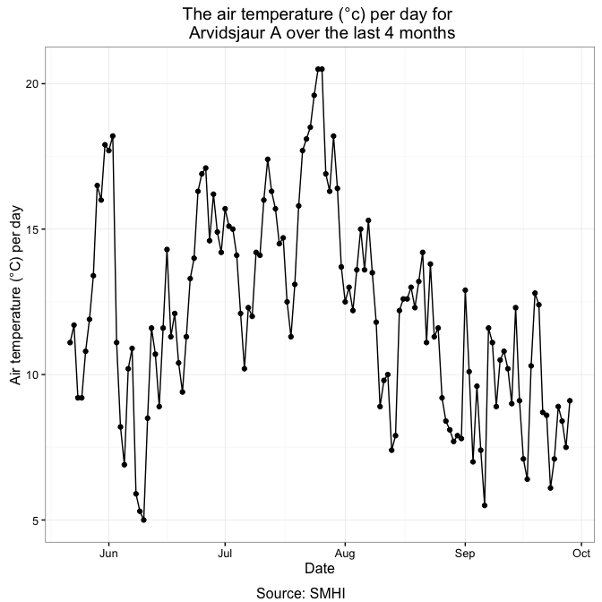

```r
smhi_plot(station=159880,parameter=2)
```

So, we can see that the autumn of 2016 has arrived to Arvidsjaur, when this vignette was written.

## Contact info

If you find any problems with the package or it’s documentation, please send us some feedback or critique. Contact Anton Persson, antpe404@student.liu.se, or Emil Klasson Svensson, emisv463@student.liu.se.